# Text Analytics

B06705015 資管二孫君傳

# Abstract

This notebook is for the homework 4~6 required in the Data Structure and Programming Design course. I use the “SMS Spam Collection Dataset” to do some text analytics. The data can be acquire from *kaggle* at [here](https://www.kaggle.com/uciml/sms-spam-collection-dataset).

# Goal

Telecommunication has always been an important aspect in the progress of our civilization. Days of waiting for the letters oversea now becomes an instant second of satellite transmission that beamed from the outer space. With the affordable cost and an efficient communication, the imformation explodes nowadays. Nevertheless, the abundant imformation seems to not be a bless, but a setback. When I started my college life, there came more and more works requiring continouosly scrutiny. Notifications from Social media, messenges from the IM software, checking requirment of assignment from school in the web and ring from my cellphone. These are all nightmare for me. To alleviate the problems, I started reduce the channel I used for communication. I told my friend only send a SMS to me in emergency, because I was discouraged from answering the call by lots of robo-calls. I seldom updates my social media, howbeit it costs me my connections to people. Mail and e-mail now becomes my main channel to buffered communication with people. Sill, as there is robo-calls for cellphone, there is also spam mail for mail. It will be proper if there is a way for the sofware to automatically detect the mail in advance and filter out those fake messenge. Otherewise, I will have to cut out all sorts of communication (It is still a way, though).

In this homework, I want to build a model that can read the messenge on tje SMS and classify it between **ham** (good) and **spam** (fake) mail. In this way, I can then write a self-programs to filter out the spam mail.

# Method

I gonna divid my work into into 4 parts: 1.Raw Data Processing 2.Training Data Processing 3.Building the model 4.Testing

## 1. Raw Data Processing

### Intall required packages

I am using the *ggplot2*, *gridExtra* library for the later visulization, *e1071* and *caret* library to arrange the data, *quanteda* library to do the majority of the text analytics, *irlba* library for some singular value decomposition and *randomForest* library for feature engineering and *lsa* for calculating the cosine similarity. We first install all the needed packages.

```r
install.packages(c("ggplot2","gridExtra","e1071", "caret", "quanteda", "irlba", "randomForest","doSNOW","lsa"))
```

### Load the data

We then load the csv data.

```r
raw <- read.csv("spam.csv",stringsAsFactors = FALSE)
head(raw)
```

|  | v1 | v2 | X | X.1 | X.2 |
| --- | --- | --- | --- | --- | --- |
| 1 | ham | Go until jurong point, crazy.. Available only in bugis n great world la e buffet... Cine there got amore wat... |  |  |  |
| 2 | ham | Ok lar... Joking wif u oni... |  |  |  |
| 3 | spam | Free entry in 2 a wkly comp to win FA Cup final tkts 21st May 2005. Text FA to 87121 to receive entry question(std txt rate)T&C's apply 08452810075over18's |  |  |  |
| 4 | ham | U dun say so early hor... U c already then say... |  |  |  |
| 5 | ham | Nah I don't think he goes to usf, he lives around here though |  |  |  |
| 6 | spam | FreeMsg Hey there darling it's been 3 week's now and no word back! I'd like some fun you up for it still? Tb ok! XxX std chgs to send, 憯1.50 to rcv |  |  |  |

The raw data contains serveral columns. The first column is the label of whether the SMS messenge is spam mail or not(ham). The second is the text for the given mail. The rest of the columns are redunctant, so we remove them and names the column for the filtered data.

### Clean the data

```r
raw <- raw[, 1:2]
names(raw) <- c("Label", "Text")
head(raw)
```

|  | Label | Text |
| --- | --- | --- |
| 1 | ham | Go until jurong point, crazy.. Available only in bugis n great world la e buffet... Cine there got amore wat... |
| 2 | ham | Ok lar... Joking wif u oni... |
| 3 | spam | Free entry in 2 a wkly comp to win FA Cup final tkts 21st May 2005. Text FA to 87121 to receive entry question(std txt rate)T&C's apply 08452810075over18's |
| 4 | ham | U dun say so early hor... U c already then say... |
| 5 | ham | Nah I don't think he goes to usf, he lives around here though |
| 6 | spam | FreeMsg Hey there darling it's been 3 week's now and no word back! I'd like some fun you up for it still? Tb ok! XxX std chgs to send, 憯1.50 to rcv |

Besides, we check whether missing values exist.

```r
sum(which(!complete.cases(raw)))
```

```
[1] 0
```

Thanks to the reliable source of data, there is no missing value. Now, the data is compact and clean. We can move on and explore it.

### Explore Raw Data

#### Distribution of the Label

Firstly, we need to know how frequent it is to receive a spam mail.

```r
prop.table(table(raw$Label))
```

```
      ham      spam
0.8659368 0.1340632
```

There are in toal 5572 piece of mail. and the propotion of the spam mail is about 13%, which is not a insignificant difference. This non-trival imbalance may be an important factor to take into account.

#### Length of Text

Secondly, we add a new feature for the length of the text, which may be a good determinant for spam detection.

```r
raw$Length <- nchar(raw$Text)
summary(raw$Length)
```

```
   Min. 1st Qu.  Median    Mean 3rd Qu.    Max.
      2      35      61      80     121     910
```

From the basic statistic, the range implies a great disparity, from minimum 2 charactors up to at most 910 letters. The median infer half of the length of text is smaller than 61, and the 19 charactors difference between the median and mean also implies a substantial skewness of the data. We use **ggplot22** to visualize the discovery.

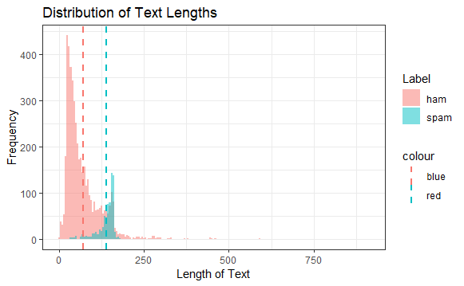

```r
m<- c(mean(raw$Length[raw$Label=="ham"]),mean(raw$Length[raw$Label=="spam"]))
library(ggplot2)
ggplot(raw, aes(x = Length, fill = Label)) +
  theme_bw() +
  geom_histogram(binwidth = 5,alpha=.5, position = "identity") +
  geom_vline(aes(xintercept=m[1],  colour="blue"),
               linetype="dashed", size=1)+
  geom_vline(aes(xintercept=m[2],  colour="red"),
               linetype="dashed", size=1)+
  labs(y = "Frequency", x = "Length of Text", title = "Distribution of Text Lengths")
```

From the histogram, we can see that not only the mean of the spam and the ham mail are different, but their direction of the skewness are also directs reversely. To be formal, let’s confirm the difference between the text length of ham and spam mail with statistical evidence.

```r
ham <- raw$Length[raw$Label == "ham"]
spam <- raw$Length[raw$Label == "spam"]
shapiro.test(ham)
```

```
    Shapiro-Wilk normality test

data:  ham
W = 0.74595, p-value < 2.2e-16
```

```r
shapiro.test(spam)
```

```
    Shapiro-Wilk normality test

data:  spam
W = 0.79345, p-value < 2.2e-16
```

Both distribution of the text length are non-normal, so we conduct the Wilcoxon Ranl Sum Test to test the population difference.
$$H_0:The\ distribution\ of\ the\ text\ length\ of\ ham\ and\ spam\ mail\ are\ the\ same$$
$$H_1:The\ distributions\ are\ different$$

```r
print(pnorm(z))
```

```
[1] 9.190584e-238
```

Because of an extremely small p-value of the Wilcoxon Ranl Sum Test, we have overwhelming evidence to infer that the text length of the ham and spam mail are different.

## 2. Training Data Processing

### Split the Data

In order to improve the model later, we segment the data into the two parts, one for training and the other testing. To do that, we use *caret* library to create a random 70/30 split, which will maintain the relative proportions of the origin, that is, about 87% ham and 13% spam.

```r
library(caret)
set.seed(32984)
index <- createDataPartition(raw$Label, times = 1, p = 0.7, list = FALSE)
train <- raw[index,]
test <- raw[-index,]
```

After the split, we verify the assumed propotion of the label.

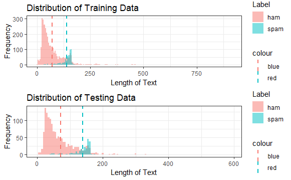

```r
library("gridExtra")
p1 <- ggplot(train, aes(x = Length, fill = Label)) +
  theme_bw() +
  geom_histogram(binwidth = 5,alpha=.5, position = "identity") +
  geom_vline(aes(xintercept=m[1],  colour="blue"),
               linetype="dashed", size=1)+
  geom_vline(aes(xintercept=m[2],  colour="red"),
               linetype="dashed", size=1)+
  labs(y = "Frequency", x = "Length of Text", title = "Distribution of Training Data")
p2 <- ggplot(test, aes(x = Length, fill = Label)) +
  theme_bw() +
  geom_histogram(binwidth = 5,alpha=.5, position = "identity") +
  geom_vline(aes(xintercept=m[1],  colour="blue"),
               linetype="dashed", size=1)+
  geom_vline(aes(xintercept=m[2],  colour="red"),
               linetype="dashed", size=1)+
  labs(y = "Frequency", x = "Length of Text", title = "Distribution of Testing Data")
grid.arrange(p1, p2, nrow = 2)
```

### Tokenization

We discompose the training data into tokens, in which the punctuation, pure numbers, stytax symbols and hyphens are removed. In addition, we also turn the capital charactor into lower case, remove the the stopword and stem the similar word to the same token in order to reduce the overall complexity of the model.

```r
library(quanteda)
train.tokens <- tokens(train$Text, what = "word",  remove_numbers = TRUE, remove_punct = TRUE, remove_symbols = TRUE, remove_hyphens = TRUE)
train.tokens <- tokens_tolower(train.tokens)
train.tokens <- tokens_select(train.tokens, stopwords(), selection = "remove")
train.tokens <- tokens_wordstem(train.tokens, language = "english")
```

#### N-grams

We also want to take the word-ordering into account, which may become an important feature providing imformation to the model. We add the bi-grams to the training data.

```r
train.tokens <- tokens_ngrams(train.tokens, n = 1:2)
```

After the bi-grams-tokenization finish, we create a document-feature matrix to represent the data, and turn it into a dataframe. Also, we clan up the column names just in fear of the invalid column name appears.

```r
train.tokens.dfm <- dfm(train.tokens, tolower = FALSE)
train.tokens.matrix <- as.matrix(train.tokens.dfm)
train.tokens.df <- cbind(Label = train$Label, convert(train.tokens.dfm,to = "data.frame"))
names(train.tokens.df) <- make.names(names(train.tokens.df))
```

#### Normalize Matrix with TF-IDF

To further enhance the efficiency of the model, let’s also apply the TF_IDF to normalize the matrix. We define our own TF and IDF function, and perform some data cleaning.

```r
##TF function
term.frequency <- function(row) {
  row / sum(row)
}
##IDF function
inverse.doc.freq <- function(col) {
  corpus.size <- length(col)
  doc.count <- length(which(col > 0))
  log10(corpus.size / doc.count)
}
##TF_TDF function
tf.idf <- function(tf, idf) {
  tf * idf
}

train.tokens.df <- apply(train.tokens.matrix, 1, term.frequency)
train.tokens.idf <- apply(train.tokens.matrix, 2, inverse.doc.freq)
train.tokens.tfidf <-  apply(train.tokens.df, 2, tf.idf, idf = train.tokens.idf)
train.tokens.tfidf <- t(train.tokens.tfidf)
```

#### Clean up data

```r
##incomplete case
incomplete.cases <- which(!complete.cases(train.tokens.tfidf))
train.tokens.tfidf[incomplete.cases,] <- rep(0.0, ncol(train.tokens.tfidf))

train.tokens.tfidf.df <- cbind(Label = train$Label, data.frame(train.tokens.tfidf))
names(train.tokens.tfidf.df) <- make.names(names(train.tokens.tfidf.df))
```

### LSA

We now use tje *irlba* library to perform a Latent Semeantic Analysis to extract the singular vector of the matrix to attain the higher-level concepts in terms of our data and reduce it into 300 column. Then we map the previous TF-IDF document into the SVD at its semantic space.

```r
library(irlba)
train.irlba <- irlba(t(train.tokens.tfidf), nv = 300, maxit = 600)

sigma.inverse <- 1 / train.irlba$d
u.transpose <- t(train.irlba$u)
document <- train.tokens.tfidf[1,]
document.hat <- sigma.inverse * u.transpose %*% document
```

### Create Refined Feature Data

Now we create a new dataframe with the original label and the 300 new features derieved from the LSA. This data become our new training data, which not only has a reduced dimension but a higher-level relationships between terms and document.

```r
train.svd <- data.frame(Label = train$Label, train.irlba$v)
```

## 3. Building the Model

### Sample for Cross-Validation

Because of the non-trival imbalance of the label previously obsered, we need to make sure that each sampling we takes is representative to the proportion of the labe, by creating 30 random stratified samples.

```r
set.seed(48743)
cv.folds <- createMultiFolds(train$Label, k = 10, times = 3)
cv.cntrl <- trainControl(method = "repeatedcv", number = 10, repeats = 3, index = cv.folds)
```

### Random Forest Model

We build the very first model for spam mail prediction with a random tree model by using the refined data we got. The calculation is time comsuming, so I package the result with the Rdata file. Feel free to run the code.

```r
library(doSNOW)
cl <- makeCluster(3, type = "SOCK")

rf.cv.1 <- train(Label ~ ., data = train.svd, method = "rf",
                 trControl = cv.cntrl, tuneLength = 7)
stopCluster(cl)
```

```r
load("rf.cv.1.RData")
rf.cv.1
```

```
Random Forest

3901 samples
 300 predictor
   2 classes: 'ham', 'spam'

No pre-processing
Resampling: Cross-Validated (10 fold, repeated 3 times)
Summary of sample sizes: 3511, 3510, 3511, 3511, 3511, 3511, ...
Resampling results across tuning parameters:

  mtry  Accuracy   Kappa
    2   0.9618038  0.8128406
   51   0.9675298  0.8446518
  101   0.9675290  0.8448381
  151   0.9675298  0.8450677
  200   0.9664192  0.8404983
  250   0.9662480  0.8396997
  300   0.9664192  0.8405704

Accuracy was used to select the optimal model using the
 largest value.
The final value used for the model was mtry = 151.
```

```r
confusionMatrix(train.svd$Label, rf.cv.1$finalModel$predicted)
```

```
Confusion Matrix and Statistics

          Reference
Prediction  ham spam
      ham  3371    7
      spam  117  406

               Accuracy : 0.9682
                 95% CI : (0.9622, 0.9735)
    No Information Rate : 0.8941
    P-Value [Acc > NIR] : < 2.2e-16

                  Kappa : 0.8497

 Mcnemar's Test P-Value : < 2.2e-16

            Sensitivity : 0.9665
            Specificity : 0.9831
         Pos Pred Value : 0.9979
         Neg Pred Value : 0.7763
             Prevalence : 0.8941
         Detection Rate : 0.8641
   Detection Prevalence : 0.8659
      Balanced Accuracy : 0.9748

       'Positive' Class : ham
```

From the confusion matrix, we can see that the total accuracy of the mail classification of the model is up to 96%. It is not a bad figure in terms of MC model, but we find that the sensitivity is lower than the specificity, which mean the model is worse at specify the ham mail. Normally, a getaway spam mail is more acceptable than a accidently removed letter. In this scenario, Type 1 error is more unaccepted.

### Add Feature of Length

To improve the sensitivity of the model, we can add another decisive feature for ham and spam mail. Recall in the previous section, we find that the length of the text is indeed a good factor to account for.

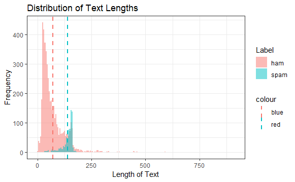

```r
m<- c(mean(raw$Length[raw$Label=="ham"]),mean(raw$Length[raw$Label=="spam"]))
ggplot(raw, aes(x = Length, fill = Label)) +
  theme_bw() +
  geom_histogram(binwidth = 5,alpha=.5, position = "identity") +
  geom_vline(aes(xintercept=m[1],  colour="blue"),
               linetype="dashed", size=1)+
  geom_vline(aes(xintercept=m[2],  colour="red"),
               linetype="dashed", size=1)+
  labs(y = "Frequency", x = "Length of Text", title = "Distribution of Text Lengths")
```

We add in the length into the training data, and run for the random tree again.

```r
train.svd$Length <- train$Length

 cl <- makeCluster(3, type = "SOCK")
 registerDoSNOW(cl)

 rf.cv.2 <- train(Label ~ ., data = train.svd, method = "rf",
                 trControl = cv.cntrl, tuneLength = 7,
                 importance = TRUE)

stopCluster(cl)
```

The result is also precompiled.

```r
load("rf.cv.2.RData")
rf.cv.2
```

```
Random Forest

3901 samples
 301 predictor
   2 classes: 'ham', 'spam'

No pre-processing
Resampling: Cross-Validated (10 fold, repeated 3 times)
Summary of sample sizes: 3511, 3510, 3511, 3511, 3511, 3511, ...
Resampling results across tuning parameters:

  mtry  Accuracy   Kappa
    2   0.9621448  0.8147416
   51   0.9705182  0.8595248
  101   0.9706898  0.8609443
  151   0.9702629  0.8587626
  201   0.9700056  0.8576510
  251   0.9689802  0.8535269
  301   0.9679543  0.8486897

Accuracy was used to select the optimal model using the
 largest value.
The final value used for the model was mtry = 101.
```

```r
confusionMatrix(train.svd$Label, rf.cv.2$finalModel$predicted)
```

```
Confusion Matrix and Statistics

          Reference
Prediction  ham spam
      ham  3375    3
      spam  110  413

               Accuracy : 0.971
                 95% CI : (0.9653, 0.9761)
    No Information Rate : 0.8934
    P-Value [Acc > NIR] : < 2.2e-16

                  Kappa : 0.8634

 Mcnemar's Test P-Value : < 2.2e-16

            Sensitivity : 0.9684
            Specificity : 0.9928
         Pos Pred Value : 0.9991
         Neg Pred Value : 0.7897
             Prevalence : 0.8934
         Detection Rate : 0.8652
   Detection Prevalence : 0.8659
      Balanced Accuracy : 0.9806

       'Positive' Class : ham
```

By adding the length feature, the specificity for the spam mail increase significantly high, but we only correct 7 cases of type 1 error compared to the previous model. We visulize the difference between adding new feature with plot.

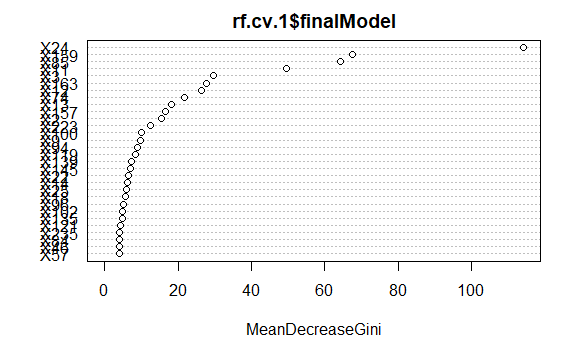

```r
library(randomForest)
varImpPlot(rf.cv.1$finalModel)
```

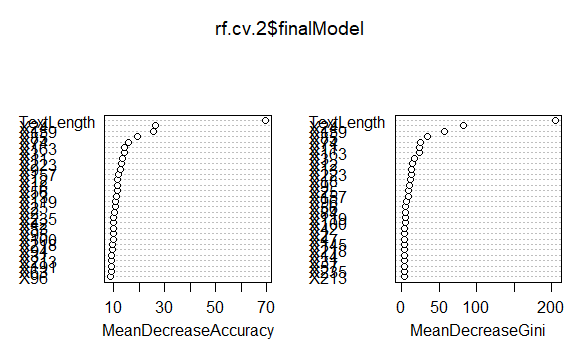

```r
varImpPlot(rf.cv.2$finalModel)
```

Those X variables are the underlying factor of the text for the spam detection model. We do not even know what does the variable really mean, but it doesn’t matter. Surprisingly, in the second plot, we observe that the added Length feature outweight the all the importance of those X variables in terms of the model. That is, the text length itself is really a good indicators.

### Cosine Similarity

We also use the *lsa* library to add the feature of cosine similarity to the model. The value was added to the new column, and we can visulize the differentiation between the ham and spam mail with a histogram.

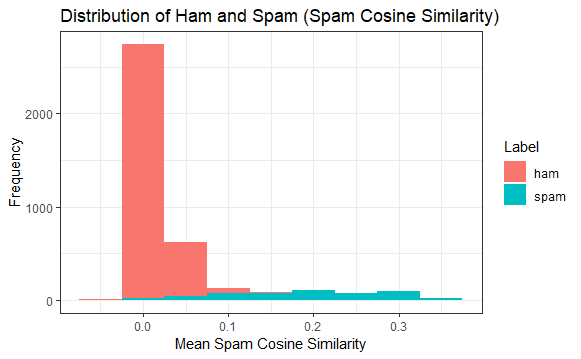

The distribution of the cosine similarity seems to be wildly different. We now build a new random tree with this new feature. Again, the result was precalculated.

```r
cl <- makeCluster(3, type = "SOCK")
registerDoSNOW(cl)

rf.cv.3 <- train(Label ~ ., data = train.svd, method = "rf",
               trControl = cv.cntrl, tuneLength = 7,
                importance = TRUE)

stopCluster(cl)
```

```r
##load("rf.cv.3.RData")
rf.cv.3
```

```
Random Forest

3901 samples
 301 predictor
   2 classes: 'ham', 'spam'

No pre-processing
Resampling: Cross-Validated (10 fold, repeated 3 times)
Summary of sample sizes: 3511, 3510, 3511, 3511, 3511, 3511, ...
Resampling results across tuning parameters:

  mtry  Accuracy   Kappa
    2   0.9641971  0.8260410
   51   0.9770999  0.8975038
  101   0.9771856  0.8990598
  151   0.9778691  0.9025640
  201   0.9770997  0.8992289
  251   0.9775277  0.9009777
  301   0.9769296  0.8983926

Accuracy was used to select the optimal model using the largest value.
The final value used for the model was mtry = 151.
```

```r
confusionMatrix(train.svd$Label, rf.cv.3$finalModel$predicted)
```

```
Confusion Matrix and Statistics

          Reference
Prediction  ham spam
      ham  3347   31
      spam   55  468

               Accuracy : 0.978
                 95% CI : (0.9728, 0.9823)
    No Information Rate : 0.8721
    P-Value [Acc > NIR] : < 2e-16

                  Kappa : 0.9032

 Mcnemar's Test P-Value : 0.01313

            Sensitivity : 0.9838
            Specificity : 0.9379
         Pos Pred Value : 0.9908
         Neg Pred Value : 0.8948
             Prevalence : 0.8721
         Detection Rate : 0.8580
   Detection Prevalence : 0.8659
      Balanced Accuracy : 0.9609

       'Positive' Class : ham
```

With the cosine similarity feature, the accuracy of the new model increases to 0.978. The accuracy of the sensitivity was sucessfully enhanced, but the spacificity dropped this time. In the scenario of spam mail detection, we are likely to prefer a better sensitivity of the model to the specificity. The improvement can also be seen with the significant difference of the improtance in the following graph.

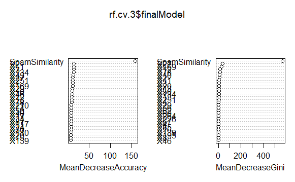

## 4. Testing

### Tokenization.

In order to test the testing data we split early, we need to convert it into the correct format. Besides, we also need to transform the testing data into exactly what the training data looks like, to do the prediction.

```r
test.tokens <- tokens(test$Text, what = "word",
                      remove_numbers = TRUE, remove_punct = TRUE,
                      remove_symbols = TRUE, remove_hyphens = TRUE)
test.tokens <- tokens_tolower(test.tokens)
test.tokens <- tokens_select(test.tokens, stopwords(),
                             selection = "remove")
test.tokens <- tokens_wordstem(test.tokens, language = "english")
test.tokens <- tokens_ngrams(test.tokens, n = 1:2)
test.tokens.dfm <- dfm(test.tokens, tolower = FALSE)

##form
test.tokens.dfm <- dfm_select(test.tokens.dfm, pattern = train.tokens.dfm,selection = "keep")
test.tokens.matrix <- as.matrix(test.tokens.dfm)

##IF_IDF
test.tokens.df <- apply(test.tokens.matrix, 1, term.frequency)

test.tokens.tfidf <-  apply(test.tokens.df, 2, tf.idf, idf = train.tokens.idf)
test.tokens.tfidf <- t(test.tokens.tfidf)

# Fix incomplete cases
test.tokens.tfidf[is.na(test.tokens.tfidf)] <- 0.0
```

With the test data projected into the TF-IDF vector space of the training, It can then be projected into the training LSA semantic. We also add the length and the similarity into the SVD to take advantage of the extra feature we derieved.

```r
test.similarities <- cosine(t(test.similarities))
```

[output not shown]

Now we can finally predict on the test data.

```r
preds <- predict(rf.cv.3, test.svd)
confusionMatrix(preds, test.svd$Label)
```

```
Confusion Matrix and Statistics

          Reference
Prediction  ham spam
      ham  1248  106
      spam  199  118

               Accuracy : 0.8175
                 95% CI : (0.7981, 0.8357)
    No Information Rate : 0.8659
    P-Value [Acc > NIR] : 1

                  Kappa : 0.3312

 Mcnemar's Test P-Value : 1.38e-07

            Sensitivity : 0.8625
            Specificity : 0.5268
         Pos Pred Value : 0.9217
         Neg Pred Value : 0.3722
             Prevalence : 0.8659
         Detection Rate : 0.7469
   Detection Prevalence : 0.8103
      Balanced Accuracy : 0.6946

       'Positive' Class : ham
```

### Alleviate the Overfitting

It seems that the model was bounded to the training data too closely. Let’s try to remove the cosine similarity to reduce the dependency to the training data.

```r
confusionMatrix(preds, test.svd$Label)
```

[output not shown]

# Conclusion

We start by processing the data, from cleaning the raw source to apply many advance technique like TF-IDF and bi-grams, just to name a few. With the suitable data form, we calls library to convert the training data into random forest model. The model was then refined for serveral times, each time we add a new feature to the model. In the eand, We try the model with the testing data, and soon encounter the overfitting problem. Finally, we can make a correct prediction on the mail fourth in five. There are still rooms to improve. For example, we can add more features, more traing data, more comination of grams, etc. Still, that will be the future project. At least for now, I can say this is my text anlytic homework for this time. Thanks for viewing!